# PORT: interpretation biases variance

Thomas McGregor

2023-05-22

# Brief

Colette and I are just discussing the design of the study in the new grant and mulling on the **impact of selecting participants with GAD7 >=8 for variance in worry, interpretation biases etc**.

In order to get a sense of this I wondered if one of you could **pull out means and SDs for worry, anxiety sensitivity, EACS, CBAS and SST (if it has been coded/cleaned)** so we can see how much variance there is in this type of selected sample. It would also be useful to see the **correlations between all of these variables and GAD7 scores** so we can see if the reduced variance has any impact on associations we’d expect to see.

## List of measures

- GAD 7
- PHQ9
- WSAS
- STAI-T
- FSS
- PMH-Scale
- PSWQ
- ASI
- CBAS
- EACS
- IUS-12
- BIS/BAS
- EPQ-R Nscale

## Notes

- SST is not clean and therefore not available for analyses

# GAD-7 scores over time

Graphic illustrating that over time (screening to baseline) and after treatment a greater number of participants fell below the IAPT GAD-7 cut-off for anxiety (>= 8).

Also, from a quick look, at screening there seems to be a few more participants that were eventually excluded that fell below 8 on the GAD-7. However, it’s only around 20 participants, so I will keep them in.

I will produce descriptives and run correlations on the baseline timepoint as it is closest to the measurement of interpretation biases. But it is worth noting that not all participants are 8 and above by this point.

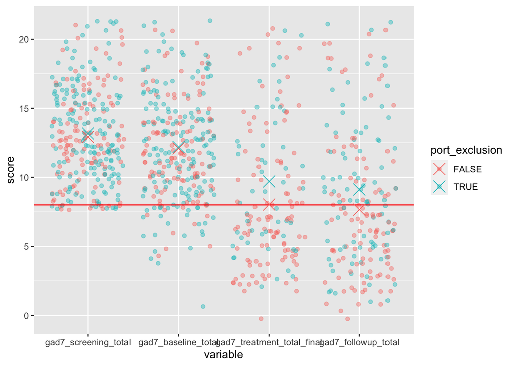

# Means and standard deviations

| Measure | Mean | SD | n |
| --- | --- | --- | --- |
| gad7 total | 12.15 | 3.71 | 292 |
| phq9 total | 13.10 | 5.21 | 292 |
| wsas total | 20.87 | 7.19 | 292 |
| stai trait total | 60.25 | 7.17 | 292 |
| fss total | 117.26 | 25.42 | 292 |
| pmh mean | 1.17 | 0.53 | 292 |
| pswq total | 66.58 | 8.79 | 292 |
| asi total | 31.22 | 12.99 | 292 |
| cbas behavioural social | 22.90 | 7.60 | 292 |
| cbas behavioural nonsocial | 18.30 | 5.48 | 292 |
| cbas cognitive social | 17.76 | 6.53 | 292 |
| cbas cognitive nonsocial | 25.61 | 8.92 | 292 |
| eacs total | 26.16 | 5.58 | 263 |
| ius12 total | 42.82 | 8.02 | 263 |
| bas drive | 9.79 | 2.50 | 262 |
| bas fun seeking | 10.47 | 2.67 | 263 |
| bas reward responsiveness | 15.81 | 2.38 | 263 |
| bis total | 25.78 | 2.28 | 263 |
| epq r nscale | 10.27 | 1.77 | 262 |

# Correlations

```
## Correlation computed with
## • Method: 'pearson'
## • Missing treated using: 'pairwise.complete.obs'
```

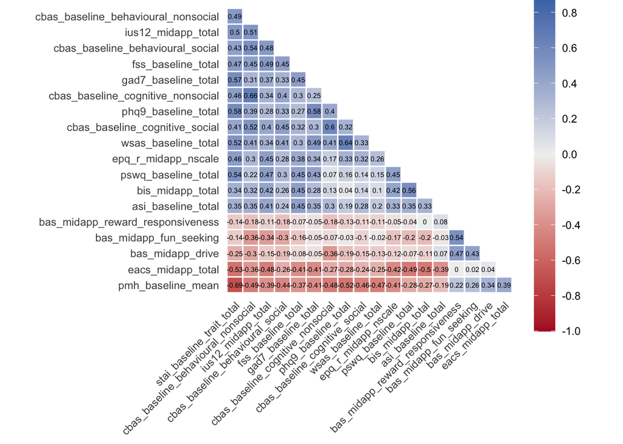